# 汇报文档

Huanghaicheng

2021-12-10

# 1 研究问题

足球点球大战中，ABBA的罚球顺序会不会比ABAB的罚球顺序更公平？不妨通过马氏链的方法来进行随机模拟研究一下。

# 2 模型一

## 2.1 模型建立

建立一个比较理想跟简单的模型。

先确定状态空间。假设每一次罚球的比分为一个状态，形式上来说就是一个二元组$(x,y)$。为了方便，不妨假设状态为一个三元组$(n,x,y)$，其中$n$为轮次（一个轮次两次罚球），$x$为第$n$轮先罚一方（下面指A队）比分，$y$为第$n$轮后罚一方（下面指B队）比分。

然后确定转移概率，只依赖于上一个状态也就是上一次罚球的比分，这里做一个重要的假设，**球队的进球概率为常值，与球队本身无关，只与当前比分状态（打平、领先、落后有关），并且领先一方更有可能继续进球，落后一方更有可能罚丢**。假设$p_1$为平局状态转为进球状态的概率，$p_2$为领先一方进球概率，$p_3$为落后一方进球概率，三者为固定值，这个假设表示为$p_2>p_1,p_3<p_1$。

## 2.2 模拟实验

```r
# 定义模拟函数：

pk.sim.1 <- function(n=10000,p1=0.6,p2=0.8,p3=0.5,draw=FALSE){
  ## 定义一些函数

  # 判断是否点球结束
  pk.end <- function(s){
    # 前三轮3-0
    if(s[[1]]==3 & abs(s[[3]]-s[[2]])==3) return(TRUE)
    # 前四轮分差大于1
    if(s[[1]]==4 & abs(s[[3]]-s[[2]])>1) return(TRUE)
    # 后面的所有轮次只要比分不同就结束
    if(s[[1]]>4 & s[[3]]!=s[[2]]) return(TRUE)

    # 其余一律未结束
    return(FALSE)
  }

  # 状态转移
  pk.trans <- function(s, team=c("A","B")){
    p <- runif(1)

    # A队罚球
    if(team=="A"){
      # 打平
      if(s[[2]]==s[[3]]){
        if(p<p1) s[[2]] = s[[2]]+1  # 进球
      }
      # 领先
      else if(s[[2]]>s[[3]]){
        if(p<p2) s[[2]] = s[[2]]+1  # 进球
      }
      # 落后
      else{
        if(p<p3) s[[2]] = s[[2]]+1  # 进球
      }
    }
    # B队罚球
    else{
      # 打平
      if(s[[2]]==s[[3]]){
        if(p<p1) s[[3]] = s[[3]]+1  # 进球
      }
      # 领先
      else if(s[[3]]>s[[2]]){
        if(p<p2) s[[3]] = s[[3]]+1  # 进球
      }
      # 落后
      else{
        if(p<p3) s[[3]] = s[[3]]+1  # 进球
      }
    }
    return(s)
  }

  # 单次模拟
  pk.ABAB <- function(){
    s <- c(0,0,0)  # 初始化状态
    while (!pk.end(s)) {
      s[[1]] <- s[[1]]+1

      # A队先罚
      s <- pk.trans(s,team = "A")

      # B队后罚
      s <- pk.trans(s,team = "B")
    }
    return(s[[2]]>s[[3]])
  }
  pk.ABBA <- function(){
    s <- c(0,0,0)  # 初始化状态
    while (!pk.end(s)) {
      s[[1]] <- s[[1]]+1

      # 奇数轮，也就是AB
      if(s[[1]]%%2){
        # A队先罚
        s <- pk.trans(s,team = "A")

        # B队后罚
        s <- pk.trans(s,team = "B")
      }
      # 偶数轮，也即BA
      else{
        # B队先罚
        s <- pk.trans(s,team = "B")

        # A队先罚
        s <- pk.trans(s,team = "A")
      }
    }
    return(s[[2]]>s[[3]])
  }

  ## 开始多次模拟
  r1 <- vector("logical",n)
  r2 <- vector("logical",n)
  for (i in 1:n) {
    r1[[i]] <- pk.ABAB()
    r2[[i]] <- pk.ABBA()
  }

  ## 绘图
  if(draw){
    library(tidyverse)
    y1 <- accumulate(r1,`+`)/(1:n)
    y2 <- accumulate(r2,`+`)/(1:n)
    draw <- tibble(x=1:n,y1=y1,y2=y2) %>%
      ggplot(aes(x=x))+
      geom_line(aes(y=y1,color=paste("ABAB,mean=",y1[[n]])))+
      geom_line(aes(y=y2,color=paste("ABBA,mean=",y2[[n]])))+
      labs(color="color",x="Simulation times",y="Ergodic mean",
           caption = paste("p1=",p1,",p2=",p2,",p3=",p3,sep = ""))
  }

  return(list(m1=mean(r1),m2=mean(r2),draw=draw))
}
```

接下来观察两种规则ABAB、ABBA下的A队胜率跟参数`p1` `p2` `p3`的关系。

不妨先假设$p_1=0.7$，对满足条件的`p2` `p3`离散化并模拟：

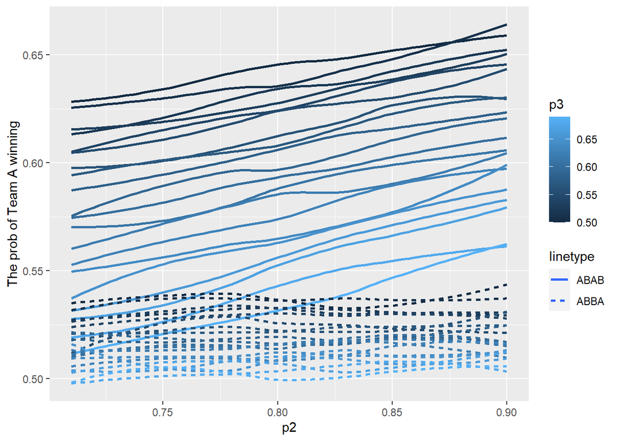

```r
p1=0.7
p2=seq(0.5,0.9,0.01)
p3=seq(0.5,0.9,0.01)
tb6 <- crossing(p1,p2,p3) %>%
  filter(p2>p1,p3<p1)  # 领先一方进球概率提高，落后一方进球概率下降

r <- pmap(tb6,pk.sim.1)
draw <- map(r,"draw")
m1 <- map_dbl(r,"m1")
m2 <- map_dbl(r,"m2")

tb6 <- tb6 %>%
  mutate(m1=m1,m2=m2,n=1:n())


tb6 %>%
  ggplot()+
  geom_smooth(aes(p2,m1,group=p3,color=p3,linetype="ABAB"),se = FALSE)+
  geom_smooth(aes(p2,m2,group=p3,color=p3,linetype="ABBA"),se = FALSE)+
  labs(y="The prob of Team A winning")
```

这表明了，ABAB规则下，A队胜率随着$p_2$的增大或$p_3$的减小而上升，也即是领先时进球率越高、落后时进球率越低（实际上就表示领先一方比落后一方有更明显的优势），A队胜率越高；ABBA规则下，A队胜率只对$p_3$的减小有小幅度的上升，并且始终在0.5-0.55附近，这表明ABBA比ABAB对于领先优势有更好的包容性，由于ABAB规则下A队更有可能获得领先优势，从而导致A队更有可能获胜，公平性不如ABBA规则。

取$p_1=0.6,0.7,0.8$，类似地按照上面的做法绘图：

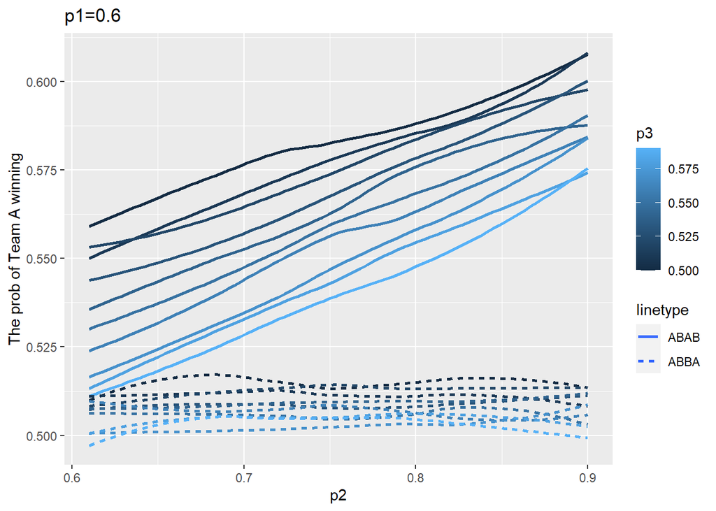

```r
p1=c(0.6,0.7,0.8)
p2=seq(0.5,0.9,0.01)
p3=seq(0.5,0.9,0.01)
tb7 <- crossing(p1,p2,p3) %>%
  filter(p2>p1,p3<p1)  # 领先一方进球概率提高，落后一方进球概率下降

r <- pmap(tb7,pk.sim.1)
m1 <- map_dbl(r,"m1")
m2 <- map_dbl(r,"m2")

tb7 <- tb7 %>%
  mutate(m1=m1,m2=m2,n=1:n())


tb7 %>%
  filter(p1==0.6) %>%
  ggplot()+
  geom_smooth(aes(p2,m1,group=p3,color=p3,linetype="ABAB"),se = FALSE)+
  geom_smooth(aes(p2,m2,group=p3,color=p3,linetype="ABBA"),se = FALSE)+
  labs(y="The prob of Team A winning",title = "p1=0.6")
```

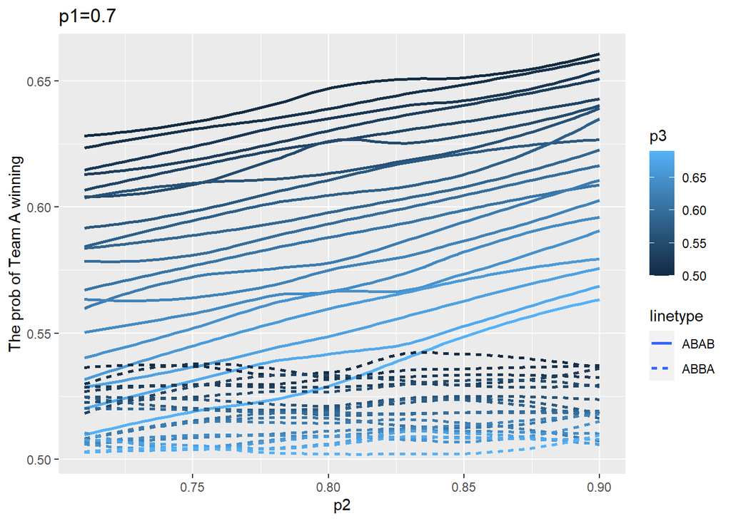

```r
tb7 %>%
  filter(p1==0.7) %>%
  ggplot()+
  geom_smooth(aes(p2,m1,group=p3,color=p3,linetype="ABAB"),se = FALSE)+
  geom_smooth(aes(p2,m2,group=p3,color=p3,linetype="ABBA"),se = FALSE)+
  labs(y="The prob of Team A winning",title = "p1=0.7")
```

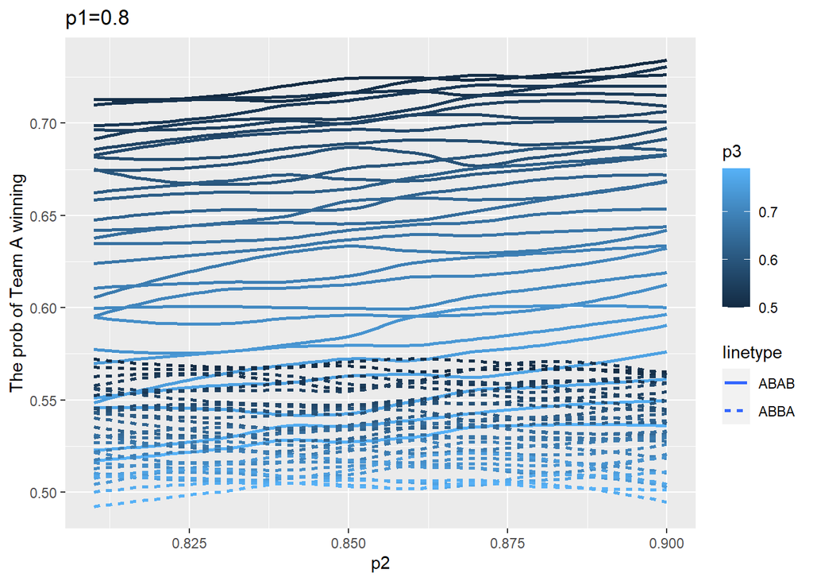

```r
tb7 %>%
  filter(p1==0.8) %>%
  ggplot()+
  geom_smooth(aes(p2,m1,group=p3,color=p3,linetype="ABAB"),se = FALSE)+
  geom_smooth(aes(p2,m2,group=p3,color=p3,linetype="ABBA"),se = FALSE)+
  labs(y="The prob of Team A winning",title = "p1=0.8")
```

可以看到，对于不同的$p_1$，对图像的趋势性影响不大，结论也跟前面一致。

# 3 模型二

## 3.1 模型建立

假设每一次罚球的命中率由三部分组成：球队的固定水平$p_A,q_B$，固定的先手优势$\Delta$，领先优势或者落后劣势$f(n)=n\alpha$，$n$为比分差。其中固定的先手优势$\Delta$由先罚一方A队先获得，若A队罚丢则由后罚一方B队获得。

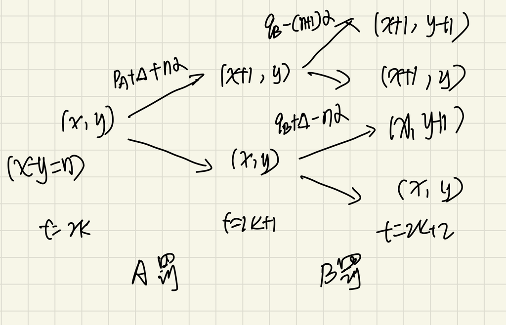

```r
knitr::include_graphics("model_AB.png")
```

如何刻画**公平性**？因为球队固定水平$p_A,q_B$可能不同，所以利用最终的A队胜率更接近0.5来刻画规则公平性是不合理的，应当把公平性刻画为对先手优势的包容性或者不敏感性，也即是在存在先手优势的情况下的A队胜率跟无先手优势的A队胜率应当相差不大。

## 3.2 模拟实验

```r
pk.sim.3 <- function(n=10000,p.A=0.7,q.B=0.68,delta=0.05,alpha=0.05){
  ## 定义一些函数

  # 传入状态三元组
  pk.end <- function(s){
    # 前三轮3-0
    if(s[[1]]==3 & abs(s[[3]]-s[[2]])==3) return(TRUE)
    # 前四轮分差大于1
    if(s[[1]]==4 & abs(s[[3]]-s[[2]])>1) return(TRUE)
    # 后面的所有轮次只要比分不同就结束
    if(s[[1]]>4 & s[[3]]!=s[[2]]) return(TRUE)

    # 其余一律未结束
    return(FALSE)
  }

  # 状态转移
  pk.AtoB <- function(s){
    p <- runif(2)
    n <- s[[2]]-s[[3]]
    if(p[[1]]<p.A+delta+n*alpha){
      s[[2]]<- s[[2]]+1
      if(p[[2]]<q.B-(n+1)*alpha) s[[3]] <- s[[3]]+1
    }else{
      if(p[[2]]<q.B+delta-n*alpha) s[[3]] <- s[[3]]+1
    }
    s[[1]] <- s[[1]]+1
    s
  }
  pk.BtoA <- function(s){
    p <- runif(2)
    n <- s[[2]]-s[[3]]
    if(p[[1]]<q.B+delta-n*alpha){
      s[[3]]<- s[[3]]+1
      if(p[[2]]<p.A+(n-1)*alpha) s[[2]] <- s[[2]]+1
    }else{
      if(p[[2]]<p.A+delta+n*alpha) s[[2]] <- s[[2]]+1
    }
    s[[1]] <- s[[1]]+1
    s
  }

  # 单次模拟
  pk.ABAB <- function(){
    s <- c(0,0,0)  # 初始化状态
    while (!pk.end(s)) {
      # A队先罚
      s <- pk.AtoB(s)
    }
    return(s[[2]]>s[[3]])
  }
  pk.ABBA <- function(){
    s <- c(0,0,0)  # 初始化状态
    while (!pk.end(s)) {
      # A队先罚
      if(s[[1]]%%2==0) s <- pk.AtoB(s)
      else s <- pk.BtoA(s)
    }
    return(s[[2]]>s[[3]])
  }

  # 多次模拟
  r1 <- vector("logical",n)
  r2 <- vector("logical",n)
  for (i in 1:n) {
    r1[[i]] <- pk.ABAB()
    r2[[i]] <- pk.ABBA()
  }

  return(list(m1=mean(r1),m2=mean(r2)))

}
```

考虑模拟结果跟$\Delta$、$\alpha$的关系。

### 3.2.1 离散化参数模拟

先假设一些参数$p_A=0.7,q_B=0.68$，然后取不同的$\Delta$跟$\alpha$，看看对最终的A队胜率的影响。

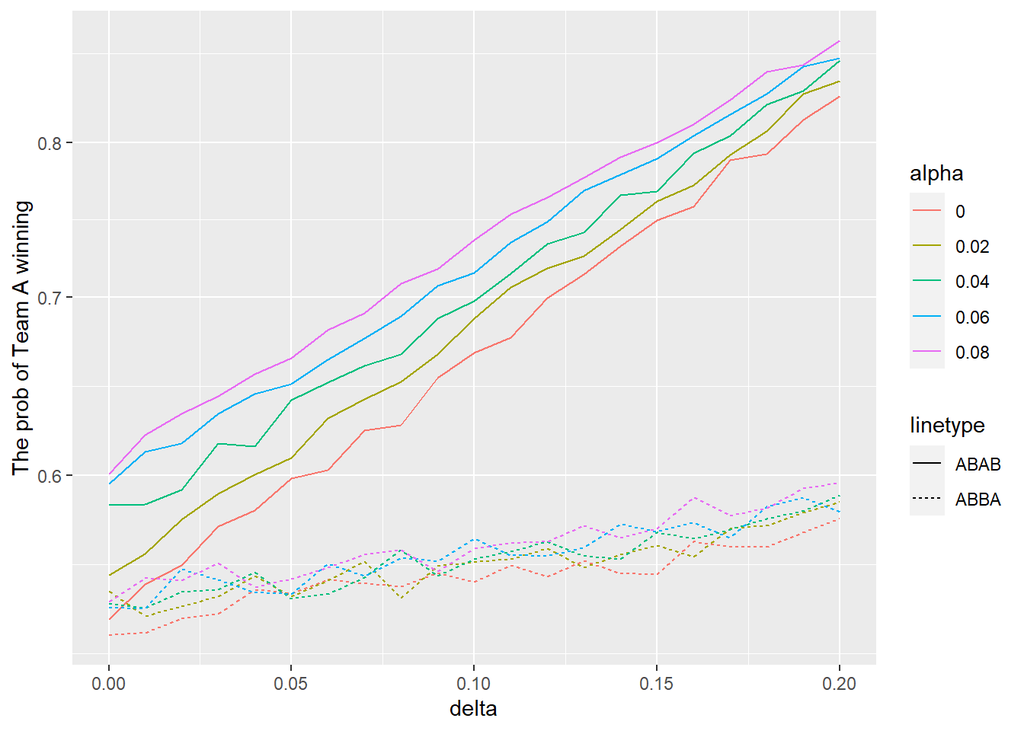

```r
# 离散化取不同的$\Delta$跟$\alpha$：

delta <- seq(0,0.2,0.01)
alpha <- seq(0,by = 0.02,length.out = 5)

#对不同的参数进行模拟：

tb4 <- crossing(delta,alpha)
a <- pmap(tb4,pk.sim.3)
tb4$m1 <- map_dbl(a,"m1")
tb4$m2 <- map_dbl(a,"m2")

# 绘图：

tb4 %>%
  mutate(alpha = factor(alpha)) %>%
  ggplot()+
  geom_line(aes(delta,m1,group=alpha,color=alpha,linetype="ABAB"))+
  geom_line(aes(delta,m2,group=alpha,color=alpha,linetype="ABBA"))+
  scale_y_continuous(trans = "log10",
                     breaks = seq(0.4,0.8,0.1))+
  labs(y="The prob of Team A winning")
```

由上图可以看到，当无先手优势跟领先优势下，也即是起点处，两种规则的A队胜率几乎一致，随着$\Delta$或者$\alpha$的增大，两种规则下的A队胜率都一定程度上增大，但是显然ABBA规则下的增大幅度更小，意味着对先手优势跟领先优势的包容性更强，也即是更公平。

也就是说，假设存在先手优势或者领先优势，那么ABBA规则依旧能够更好地维持两队的公平。

接下来看看对于几个不同的$p_A,q_B$组合的变化情况。

```r
delta <- seq(0,0.2,0.01)
alpha <- seq(0,by = 0.02,length.out = 5)
p.A <- c(0.68,0.7,0.72)
q.B <- c(0.68,0.7,0.72)

tb5 <- crossing(p.A,q.B,delta,alpha)
a <- pmap(tb5,pk.sim.3)
tb5$m1 <- map_dbl(a,"m1")
tb5$m2 <- map_dbl(a,"m2")
```

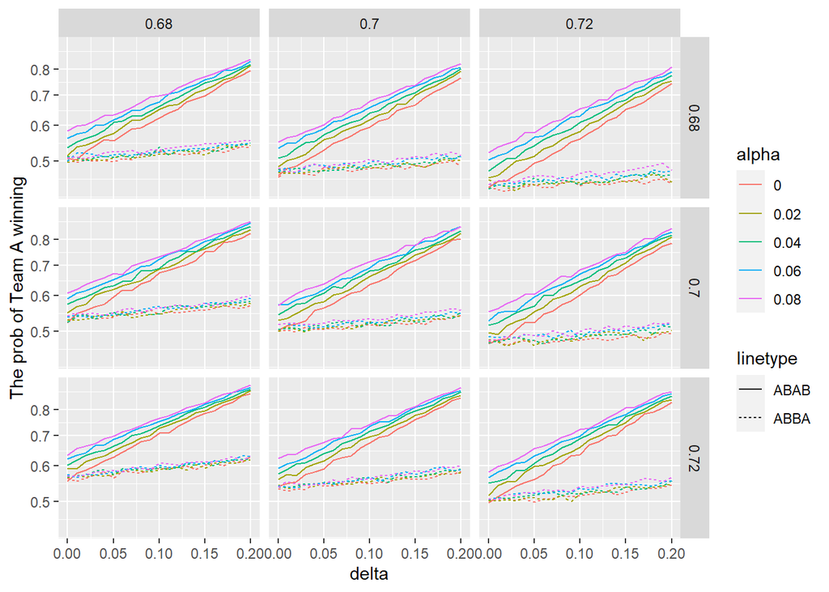

```r
tb5 %>%
  mutate(alpha = factor(alpha)) %>%
  ggplot()+
  geom_line(aes(delta,m1,group=alpha,color=alpha,linetype="ABAB"))+
  geom_line(aes(delta,m2,group=alpha,color=alpha,linetype="ABBA"))+
  scale_y_continuous(trans = 'log10',breaks = seq(0.4,0.8,0.1))+
  labs(y="The prob of Team A winning")+
  facet_grid(p.A~q.B)
```

`p.A`表示每一行，`q.B`表示每一列。可以看到，每个图像的形状与先前差别不大。`q.B`固定，随着`p.A`的增大，A队胜率上移，同理也有，`p.A`固定，随着`q.B`的增大，B队胜率上移，也即是球队的点球固定水平越高，更有可能获胜。观察一下对角线，当$p_A=q_B$时，无先手优势跟领先优势下两种规则的A队胜率都在0.5附近，与直觉一致。

可以猜想一下，`p.A`与`q.B`的值不会影响图像的大致形状，只会影响起点（无先手优势跟领先优势）。

### 3.2.2 估计参数模拟

对某场具体的比赛，估计下参数$p_A,q_B$，再进行实验模拟。

以2020年欧洲杯决赛意大利对英国的比赛为例，先看看两队的罚球球员，再利用这些球员的历史点球数据的均值（总进球/总点球）估计该球队的点球固定水平。

比赛中，意大利队先踢，罚球人员以此为：Berardi、Belotti、Bonucc、Bernardeschi、Jorginho；英格兰队后踢，罚球人员依次为：Kane、Maguire、Rashford、Sancho、Saka。数据来源是：https://www.transfermarkt.com/ ，但有个小问题就是这里面的球员历史点球数据只包括常规时间的点球，不包括点球大战的点球数据。下面通过他们的历史点球数据来估计球队点球固定水平：

```r
# 意大利
Italy.scored <- c(35,31,2,11,29)  # 各个球员罚进数据
Italy.missed <- c(7,8,0,1,5)  # 各个球员罚丢数据
p.Italy <- sum(Italy.scored)/sum(Italy.scored+Italy.missed)

# 英格兰
Eng.scored <- c(45,0,15,10,2)
Eng.missed <- c(8,0,2,1,1)
p.Eng <- sum(Eng.scored)/sum(Eng.scored+Eng.missed)

cat("点球固定水平，意大利：",p.Italy,"，英国：",p.Eng)
```

```
## 点球固定水平，意大利： 0.8372093 ，英国： 0.8571429
```

利用该参数以及离散化其余参数进行模拟实验：

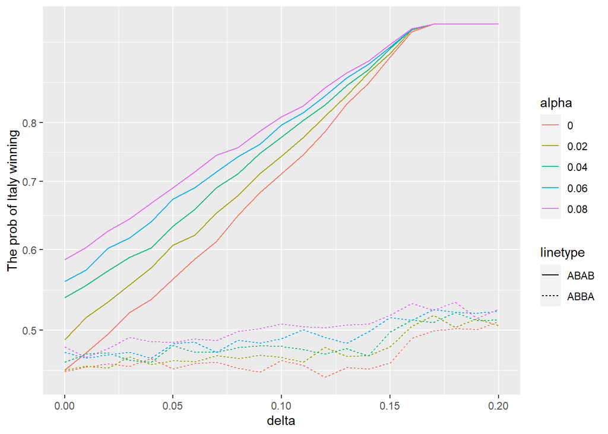

```r
delta <- seq(0,0.2,0.01)
alpha <- seq(0,by = 0.02,length.out = 5)
p.A <- p.Italy
q.B <- p.Eng
tb8 <- crossing(p.A,q.B,delta,alpha)
a <- pmap(tb8,pk.sim.3)
tb8$m1 <- map_dbl(a,"m1")
tb8$m2 <- map_dbl(a,"m2")

# 绘图
tb8 %>%
  mutate(alpha = factor(alpha)) %>%
  ggplot()+
  geom_line(aes(delta,m1,group=alpha,color=alpha,linetype="ABAB"))+
  geom_line(aes(delta,m2,group=alpha,color=alpha,linetype="ABBA"))+
  scale_y_continuous(trans = 'log10',breaks = seq(0.4,0.8,0.1))+
  labs(y="The prob of Italy winning")
```

上图表明了，假设先手优势跟领先优势存在，那么随着两者的增大，ABAB规则下意大利队胜率会急剧上升，而ABBA规则下则比较平稳。所以总的来说，ABBA要比ABAB要更公平一下。并且我们有理由说明，英国最后输掉点球很可能是由于规则上的不公平。

# 4 理论分析

前面都是通过模拟实验得到的结果进行分析，下面我们希望在理论上进行分析。

## 4.1 只考虑前5轮

利用前面建立的模型可以得到，ABAB规则下前5轮A队的胜、平、负概率为$p_1,p_2,p_3$，ABBA规则下前5轮A队的胜、平、负概率为$p_4,p_5,p_6$。

每一个$p_i$可以表示为关于$\Delta$的多项式，由模拟图像可以看出胜率大致呈线性趋势，并且$\Delta$的值较小，故我们不妨只考虑常数项跟一次项，即
$$p_i = c_{0i}+c_{1i}\Delta+O(\Delta^2)\approx c_{0i}+c_{1i}\Delta$$

我们希望能够证明，$c=c_{11}-c_{14}>0$（不妨称之为相对不公平性），也即是ABAB规则下前5轮A队胜率随$\Delta$的变化率比ABBA规则下的要大。

注意到$c$可以改成成$c=P^Td(\alpha)Q$，其中$P=(1,p_A,p_A^2,p_A^3,p_A^4,p_A^5)^T,Q=(1,q_B,q_B^2,q_B^3,q_B^4,q_B^5)$，$d(\alpha)$是矩阵，每个元素是关于$\alpha$的多项式。

我们不妨只考虑$p_A=q_B$的情况，这样就可以转化为二次型的问题，我们只需证明$d(\alpha)$正定。

由于$\alpha$取值较小，我们可以同样近似：
$$d(\alpha)=d_0+d_1\alpha+O(\alpha^2)\approx d_0+d_1\alpha$$
其中$d_0,d_1$为常数矩阵。由正定性的线性性，问题可以进一步转化为证明$d_0,d_1$正定。

### 4.1.1 思路1

注意到$d_i$不唯一，我们可以考虑直接构造一个正定的$d_i$，从而达到证明。并且我们已经利用MATLAB求得其中一个$d_0,d_1$:

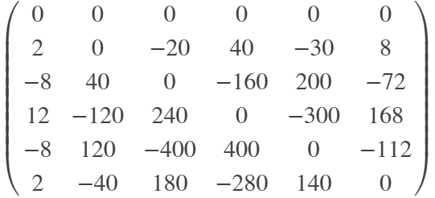

```r
knitr::include_graphics("d0.png")
```

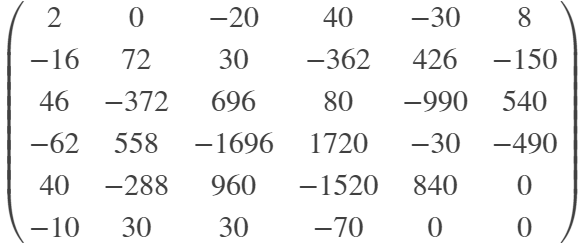

```r
knitr::include_graphics("d1.png")
```

### 4.1.2 思路2

记$c_0=P^Td_0P,c_1=P^Td_1P$，注意到$c_0,c_1$都是关于$p_A$的多项式，且$p_A\in[0,1]$。要证$d_0,d_1$正定，可以考虑直接证多项式$c_0,c_1$在$[0,1]$上大于0。

利用数值模拟的方法可以得到：

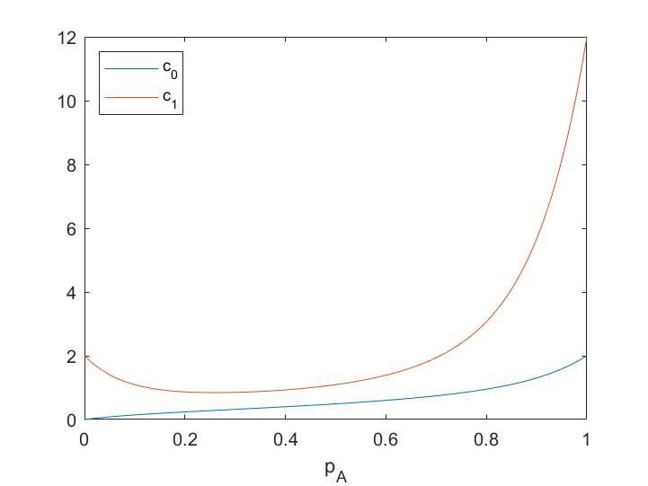

```r
knitr::include_graphics("sim_c0_c1.png")
```

可以看到这个结论应当是对的。当然，能在理论上说明会更好。

进一步的，我们可以考虑当$p_A\ne q_B$的情况，也即$P\ne Q$时，此时$c_0=P^Td_0Q,c_1=P^Td_1Q$，它们对于不同的$(p_A,q_B)$组合是否也大于0？

利用数值模拟的方法可以得到：

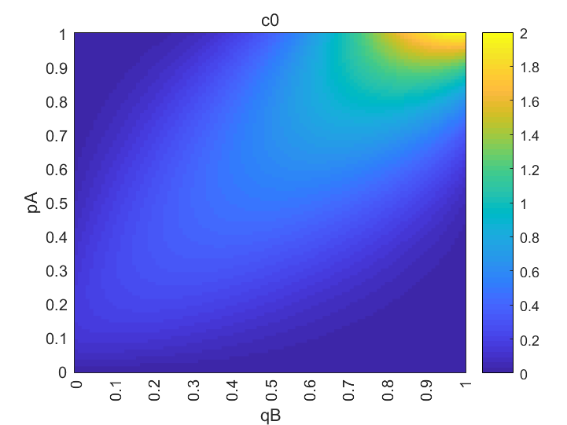

```r
knitr::include_graphics("sim_c0.png")
```

可以看到，对于任意$(p_A,q_B)$组合，$c_0\ge0$。

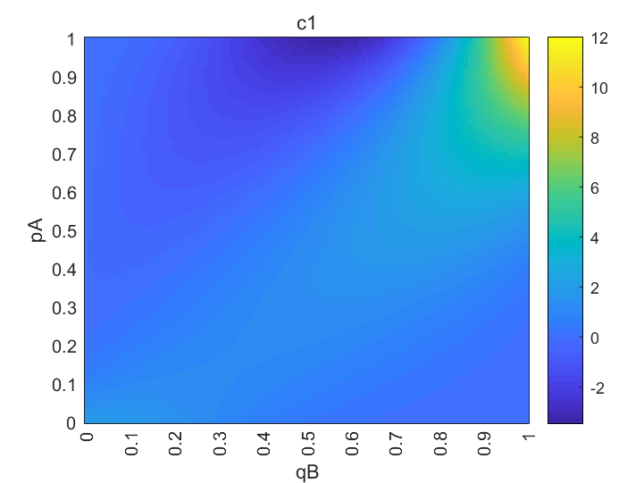

```r
knitr::include_graphics("sim_c1.png")
```

而对于$c_1$，会存在区域使得$c_1<0$，考虑这部分区域的分布：

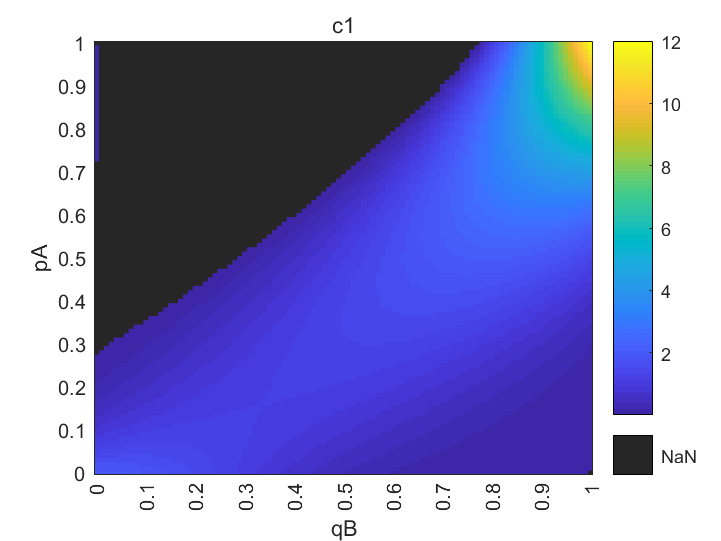

```r
knitr::include_graphics("sim_c1_ge0.png")
```

## 4.2 考虑所有轮次

5轮之后各规则下每轮的A队胜、平、负概率与轮数无关，记$q_1,q_2,q_3$分别为5轮后A队先踢的每一轮中A队的胜、平、负概率，$q_4,q_5,q_6$分别为5轮后B队先踢的每一轮中A队的胜、平、负概率。

可以计算得到ABAB规则下A队最终胜率$P_A=p_1+p_2\dfrac{q_1}{q_1+q_3}$，以及ABBA规则下A队最终胜率$Q_A=p_4+p_5\dfrac{q_4+q_5q_1}{1-q_5q_2}$。由于$q_i$都是关于$\Delta$的多项式，故$P_A,Q_A$都不再是多项式，而是有理式，分析起来比较困难。

一种方法是对$P_A,Q_A$的分母（关于$\Delta$多项式）$1/(q_1+q_3),1/(1-q_5q_2)$Taylor展开到2阶，它就可以近似为一个多项式，再与多项式相乘仍是多项式，记这样处理得到的关于$\Delta$的多项式为$\tilde{P_A},\tilde{Q_A}$。

# 5 数值分析

## 5.1 只考虑前5轮

离散化$\alpha=0:0.01:0.1,p_A=0.5:0.01:0.9,q_B=0.5:0.01:0.9$，求$c$的值，并绘图：

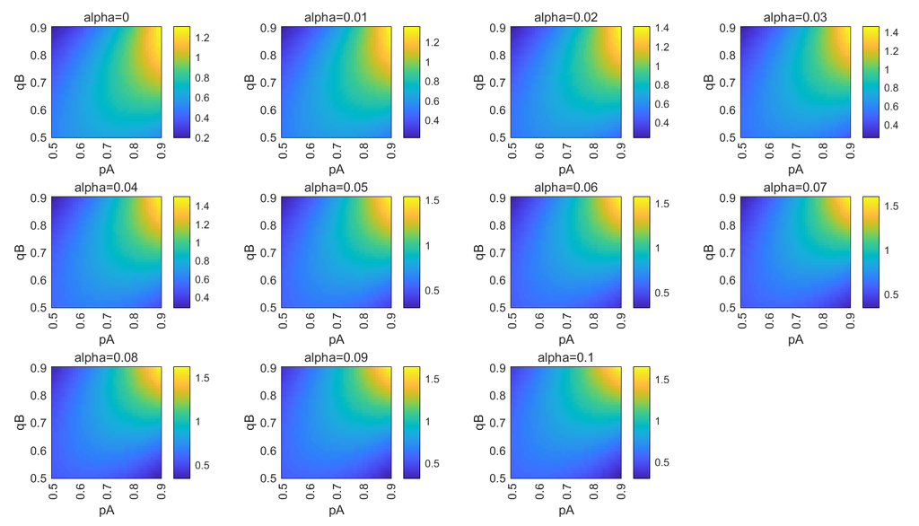

```r
knitr::include_graphics("sim_5_round.png")
```

## 5.2 考虑所有轮次

类似于前5轮，离散化$\alpha=0:0.01:0.1,p_A=0.5:0.01:0.9,q_B=0.5:0.01:0.9$，求$\tilde{P_A},\tilde{Q_A}$关于$\Delta$一次项系数的差，并绘图：

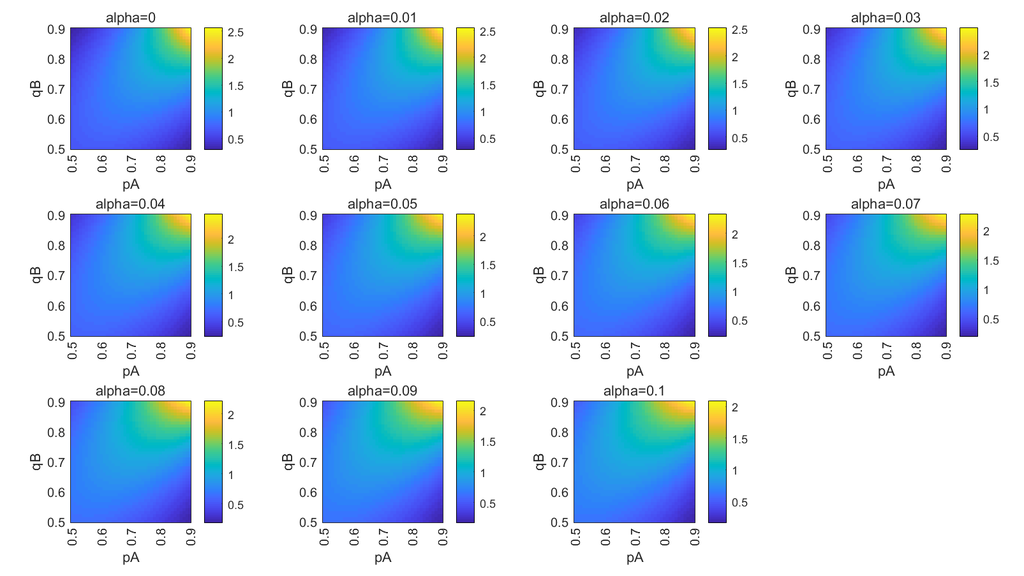

```r
knitr::include_graphics("sim_mult_round.png")
```

## 5.3 图像分析

两幅图大致一致（峰值不同），表示的含义是，当$p_A,q_B$较大且相差较小时，ABAB规则下A队胜率关于$\Delta$的变化率比ABBA规则下的要更大，也即是，当两队固有水平都很高并且也很接近的时候，ABAB规则相对于ABBA规则的不公平性体现得更突出。